# Multi-site fMRI analysis using privacy-preserving federated learning and domain adaptation: ABIDE results - ScienceDirect

#### 4.4.2. MoE Gating value

The core of MoE was to mix the outputs of a collaboratively-learned global model and a private model in each site. Over time, a site’s gate function *a*(*x*) learned whether to trust the global model or the private model more for a given input. The private model needed to perform well on only the subset of the data points for which the global model failed. While the global model still benefited from the data product (model weights) sharing but received weaker updates on these hard ”private” data points. This meant that users with unusual domains had a smaller effect on the global model, which might increase their ability to generalize (Ji et al., 2019). We show the gating value associated with a federated global model for each testing data point in Fig. 9. Again, we noticed that the gating values were almost uniformly distributed in the range [0,1], which meant the MoE layer functioned as an inter-medium to coordinate the decisions of the private and global model, except that the gating values of USM site were skewed to 0s and 1s. This showed evidence for why *Fed-MoE* did not perform better than *Fed* on the USM site.

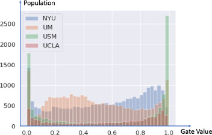

1. [Download : Download high-res image (129KB)](https://ars.els-cdn.com/content/image/1-s2.0-S1361841520301298-gr9_lrg.jpg)
2. [Download : Download full-size image](https://ars.els-cdn.com/content/image/1-s2.0-S1361841520301298-gr9.jpg)

Fig. 9. The histogram of MoE gated values assigned to federated global model.

#### 4.4.3. Neural patterns: Connectivity in the autistic brain

Note that we defined ”informativeness” as the difference of functional representations between ASD and HC groups and ”robustness” as the consistency of biomarker detection results across 4 sites. Whether informative and robust biomarkers can be interpreted is another dimension to evaluate a deep learning model apart from using accuracy-related metrics. Here, we used the guided back-propagation method (Eq. 9) to interpret feature importance on *Fed* and *Single* model separately. The features of inputs were the functional connectivity between brain ROIs. First, we calculated $gc=[gkc]k=16105$ for each testing point. To get the ROI level evaluation, we built a symmetric *grad* matrix $G$ where the *ij*th entry is the *g<sup>c</sup>* of functional connectivity between ROI *i* and *j*. We summed $G$ over columns resulting in a 111-dim vector *s<sup>c</sup>* standing for the importance score of the 111 ROIs. We normalized $sc=[src]r=1111$ by dividing *max*(*s<sup>c</sup>*) to bound it to [0,1]. We averaged the results for all the test data points in each site. The ROIs with the top 10 important scores for classification (2 classes) and normalized importance scores on the ROIs were plotted for HC (Fig. 10) and ASD (Fig. 11). *Fed* detected **robust** biomarkers across 4 sites, while the biomarkers detected by *Single* were different across different sites. Further, we listed the correlations between the biomarkers with functional keyword maps in Table 4 by Neurosynth (Yarkoni et al., 2011). The biomarkers detected by *Fed* were more distinguishable than those of *Single*, as the differences between correlation values for HC and ASD group were larger than those of *Single* (see the |Δ| scores of *Fed* are larger than those of *Single* in Table 4). Therefore, we found the biomarkers detected by *Fed* were more informative. We could infer from Table 4 that the semantic, comprehension, social and attention-related functional connectivity was more salient in the HC group, while memory and reward-related functional connectivity was more salient in the ASD group. Hence, the biomarkers detected by *Fed* were more robust and informative. The names of the biomarkers of each group detected by *Fed* and *Single* were listed in the Appendix.

[figure not shown]

1. [Download : Download high-res image (802KB)](https://ars.els-cdn.com/content/image/1-s2.0-S1361841520301298-gr10_lrg.jpg)
2. [Download : Download full-size image](https://ars.els-cdn.com/content/image/1-s2.0-S1361841520301298-gr10.jpg)

Fig. 10. Interpreting brain biomarkers associated with identifying **HC** from federated learning model (*Fed*) and using single site data for training (*Single*). The colors stand for the relative importance scores of the ROIs and the values are denoted on the color bar. The names of the strategies and sites are denoted on the left-upper corners of each subfigure. Each row shows the results of NYU, UM, USM, UCLA site from top to bottom. (For interpretation of the references to colour in this figure legend, the reader is referred to the web version of this article.)

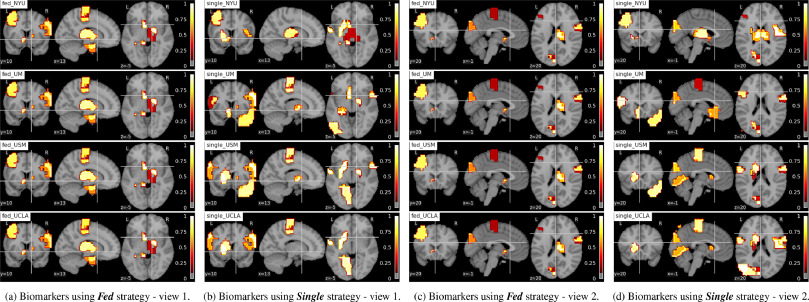

1. [Download : Download high-res image (1MB)](https://ars.els-cdn.com/content/image/1-s2.0-S1361841520301298-gr11_lrg.jpg)
2. [Download : Download full-size image](https://ars.els-cdn.com/content/image/1-s2.0-S1361841520301298-gr11.jpg)

Fig. 11. Interpreting brain biomarkers associated with identifying **ASD** from federated learning model (*Fed*) and using single site data for training (*Single*). The colors stand for the relative importance scores of the ROIs and the values are denoted on the color bar. The names of the strategies and sites are denoted on the left-upper corners of each subfigure. Each row shows the results of NYU, UM, USM, UCLA site from top to bottom.. (For interpretation of the references to colour in this figure legend, the reader is referred to the web version of this article.)

Table 4. Correlations between the detected biomarkers and functional keywords maps decoded by Neurosynth.

|  |  | Sementic | Comprehension | Social | Attention | Memory | Reward |
| --- | --- | --- | --- | --- | --- | --- | --- |
| Fed | HC | 0.054 | 0.096 | 0.099 | 0.088 | 0.009 | −0.078 |
|  | ASD | −0.048 | −0.035 | −0.081 | 0.007 | 0.031 | 0.017 |
|  | **\|Δ\|** | **0.102** | **0.131** | **0.180** | **0.081** | **0.022** | **0.095** |
| Single | HC | 0.050 | 0.043 | 0.069 | 0.053 | 0.022 | −0.062 |
|  | ASD | −0.029 | −0.005 | −0.094 | 0.005 | 0.041 | 0.010 |
|  | **\|Δ\|** | **0.079** | **0.048** | **0.163** | **0.048** | **0.019** | **0.072** |

|Δ| is the absolute difference between the scores of HC and ASC groups.

### 4.5. Limitation and discussion

Although, based on our empirical investigation that the communication pace, which controled how often the local and global model update the weight information, did not affect the classification performance, we could not draw the conclusion that the pace parameter was irrelevant. A more extensive range of pace values should be examined according to the application. Also, we used practical approaches to investigate privacy-preserving mechanisms. However, the sensitivity of the mapping function $h:D→Rm,$ the deep learning classifier in our case, was difficult to estimate. Hence, we did not explicitly give the bound ϵ. A recent study (Zhu et al., 2019) also demonstrated Gaussian and Laplace noise higher than a certain scale can be a good defense to reconstruction attack. According to the specific application and dataset, we can empirically estimate a suitable noise level from attacking perspective as well. In our experiments, we used the averaging method to incorporate models’ outputs for *Ensemble*. To achieve better performance for *Ensemble*, more advanced ensemble methods could be exploited, such as gradient tree boosting, stacking, and forest of randomized trees (Zhou, 2012). We evaluated the biomarkers at the ROI-level. The functional connectivity also could be used as biomarkers. More advanced deep learning models can be explored as well. In order to show the strong direct associations between the biomarkers and disease diagnosis or treatment outcome prediction, down-stream tasks such as regression to ADOS scores using the biomarkers are worthy of exploring. We found that domain adaptation methods were not always a beneficial addition to the federated model. Based on the results presented in Section 4.3 and Section 4.4, we found that domain adaption techniques improved the classification accuracy of some sites but not all (two out of four sites were better and one site kept the same for *MoE* and *MoE* by comparing mean accuracies). This could be because the current model updating strategy is not optimal. Going forward, we plan to examine the distribution of the latent features of different data owners first, then decide whether to adopt our proposed domain adaptation methods. In contrast to other FL applications, such as typing recommendations in Google and Apple, where there might be millions of FL participants, there are many fewer participants in multi-site medical data analysis. Hence, the number of FL participants might play a role here, especially if we use an averaging strategy to update the global model. Incorporating more advanced model-selection and updating strategies will help avoid including the wrong private model in updating (Mohri, Sivek, Suresh, 2019, Nishio, Yonetani, 2019).

## 5. Conclusion

In this work, we have presented a privacy-preserving federated learning framework for multi-site fMRI analysis. We have investigated the communication pace and the privacy-preserving randomized mechanisms for the problem of using brain functional connectivity to classify ASD and HC. To overcome the domain shift issue, we have proposed two strategies: MoE and adversarial domain alignment to boost federated learning model performance. We have also evaluated the deep learning model for neuroimaging from the biomarker detection perspective.

Our results have demonstrated the advantage of using a federated framework to utilize multi-site data without data sharing compared to alternative methods. We have shown federated learning performance can potentially be boosted by adding domain adaptation and discussed the condition of benefits. In addition, the proposed federated learning model has revealed possible brain biomarkers for identifying ASD. Our work also has broader implications into other disease areas, particularly rare diseases with fewer patients. In these situations, utilizing data across multiple sites is critical and required for meaningful conclusions.

Our approach brings new hope for accelerating deep learning applications in the field of medical imaging, where data isolation and the emphasis on data privacy have become challenges. It can establish a unified model for multiple medical institutions while protecting local data, allowing medical institutions to work together with the required data security.

## Declaration of Competing Interest

The authors declare that they have no known competing financial interests or personal relationships that could have appeared to influence the work reported in this paper.

## Acknowledgements

Data were provided by the Autism Brain Imaging Data Exchange dataset (ABIDE) (Di Martino et al., 2014). Parts of this research was supported by National Institutes of Health (NIH) [R01NS035193, R01MH100028].

## Appendix

### A. Architecture of the models

We provide the detailed model architecture for each strategy we used in our study. For each fully connected (FC), we provide the input and output dimension. For drop-out (Dropout) layers, we provide the probability of an element to be zeroed. We denote batch normalization layers as (BN), relu layers as (ReLU) and softmax layers as Softmax.

Models for *Single, Cross* and *Ensemble* are shown in Table 5.

Table 5. Model architecture for ABIDE rs-fMRI classification task under *Single, Cross* and *Ensemble* strategies.

| Layer MLPs | Configuration MLPs |
| --- | --- |
| 1 | Dropout (0.5), FC (6105, 8), ReLU, BN |
| 2 | Dropout (0.5), FC (8, 2), Softmax |

Table 6. Model architecture for ABIDE rs-fMRI classification task under *Fed* and *Mix* strategies.

| Layer MLPs | Configuration MLPs |
| --- | --- |
| 1 | Dropout (0.5), FC (6105, 16), ReLU, BN |
| 2 | Dropout (0.5), FC (16, 2), Softmax |

Models for *Fed-MoE* strategy is shown in Table 7.

Table 7. Model architecture for ABIDE rs-fMRI classification task under Fed-MoE strategy.

| Layer Private Model | Configuration Private Model | Layer Global Model | Configuration Global Model |
| --- | --- | --- | --- |
| 1 | Dropout (0.5), FC (6105,8), ReLU, BN | 1 | Dropout (0.5), FC (6105,16), ReLU, BN |
| 2 | Dropout (0.5), FC (8,2) | 2 | Dropout (0.5), FC (16,2) |
| Layer | Configuration |  |  |
| MoE |  |  |  |
| 1 | FC (2,1), Sigmoid |  |  |

Models for *Fed-Align* strategy is shown in Table 8

Table 8. Model architecture for ABIDE rs-fMRI classification task under Fed-Align strategy.

[output not shown]

### B. Names of the biomarkers

We list the top 10 important ROIs (plotted in Fig. 10 and Fig. 11 in descending order.

1. HC biomarkers detected by *Fed*:

[NYU]: ‘Right Heschl’s Gyrus (includes H1 and H2)’ ‘Right Inferior Temporal Gyrus’ ‘Right Superior Frontal Gyrus’ ‘Right Precentral Gyrus’ ‘Left Intracalcarine Cortex’ ‘Left Cingulate Gyrus’ ‘Left Temporal Pole’ ‘Right Superior Temporal Gyrus’ ‘Right Middle Temporal Gyrus’ ‘Left Planum Polare’

[UM]: ‘Right Heschl’s Gyrus (includes H1 and H2)’ ‘Right Inferior Temporal Gyrus’ ‘Right Superior Frontal Gyrus’ ‘Right Precentral Gyrus’ ‘Left Intracalcarine Cortex’ ‘Left Cingulate Gyrus’ ‘Right Superior Temporal Gyrus’ ‘Left Temporal Pole’ ‘Right Middle Temporal Gyrus’ ‘Left Planum Polare’

[USM]: ‘Right Heschl’s Gyrus (includes H1 and H2)’ ‘Right Inferior Temporal Gyrus’ ‘Right Superior Frontal Gyrus’ ‘Right Precentral Gyrus’ ‘Left Intracalcarine Cortex’ ‘Left Cingulate Gyrus’ ‘Right Middle Temporal Gyrus’ ‘Left Planum Polare’ ‘Right Superior Temporal Gyrus’ ‘Left Temporal Pole’

[UCLA]: ‘Right Heschl’s Gyrus (includes H1 and H2)’ ‘Right Superior Frontal Gyrus’ ‘Right Inferior Temporal Gyrus’ ‘Right Precentral Gyrus’ ‘Left Intracalcarine Cortex’ ‘Left Cingulate Gyrus’ ‘Left Temporal Pole’ ‘Right Superior Temporal Gyrus’ ‘Right Middle Temporal Gyrus’ ‘Left Planum Polare’

2. HC biomarkers detected by *Single*:

**•**

[NYU]: ‘Right Middle Temporal Gyrus’ ‘Right Occipital Pole’ ‘Right Supramarginal Gyrus’ ‘Left Paracingulate Gyrus’ ‘Right Precentral Gyrus’ ‘Right Frontal Orbital Cortex’ ‘Right Temporal Pole’ ‘Right Frontal Medial Cortex’ ‘Right Parahippocampal Gyrus’ ‘Left Parietal Operculum Cortex’

**•**

[UM]: ‘Right Supramarginal Gyrus’ ‘Right Middle Temporal Gyrus’ ‘Left Inferior Temporal Gyrus’ ‘Left Inferior Frontal Gyrus’ ‘Left Paracingulate Gyrus’ ”Right Heschl’s Gyrus (includes H1 and H2)” ‘Left Lingual Gyrus’ ‘Right Superior Temporal Gyrus’ ‘Left Frontal Orbital Cortex’ ‘Left Superior Temporal Gyrus’

**•**

[USM]: ‘Right Middle Temporal Gyrus’ ‘Right Supramarginal Gyrus’ ‘Left Superior Temporal Gyrus’ ‘Right Occipital Pole’ ‘Left Paracingulate Gyrus’ ‘Right Precentral Gyrus’ ‘Left Inferior Temporal Gyrus’ ‘Left Middle Temporal Gyrus’ ‘None’ ‘Left Hippocampus’

**•**

[UCLA]: ‘Right Supramarginal Gyrus’ ‘Right Middle Temporal Gyrus’ ‘Right Occipital Pole’ ‘Right Precentral Gyrus’ ‘Right Temporal Occipital Fusiform Cortex’ ‘Left Lingual Gyrus’ ‘Left Inferior Temporal Gyrus’ ‘Left Paracingulate Gyrus’ ‘Right Cingulate Gyrus’ ‘Left Inferior Frontal Gyrus’

3. ASD biomarkers detected by *Fed*:

**•**

[NYU]: ‘Left Accumbens’ ‘Left Parahippocampal Gyrus’ ‘Right Thalamus’ ”Right Heschl’s Gyrus (includes H1 and H2)” ‘Right Pallidum’ ‘Left Middle Frontal Gyrus’ ‘Right Precentral Gyrus’ ‘Right Parahippocampal Gyrus’ ‘Left Cuneal Cortex’ ‘Left Temporal Fusiform Cortex’

**•**

[UM]: ‘Left Accumbens’ ‘Left Frontal Operculum Cortex’ ‘Right Thalamus’ ‘Right Lateral Occipital Cortex’ ‘Right Pallidum’ ‘Left Postcentral Gyrus’ ‘Left Juxtapositional Lobule Cortex (formerly Supplementary Motor Cortex)’ ‘Right Middle Frontal Gyrus’ ‘Right Occipital Fusiform Gyrus’ ‘Left Central Opercular Cortex’

**•**

[USM]: ‘Left Accumbens’ ‘Left Frontal Operculum Cortex’ ‘Right Thalamus’ ‘Right Pallidum’ ‘Right Lateral Occipital Cortex’ ‘Left Juxtapositional Lobule Cortex (formerly Supplementary Motor Cortex)’ ‘Left Postcentral Gyrus’ ‘Right Middle Frontal Gyrus’ ‘Left Central Opercular Cortex’ ‘Right Occipital Fusiform Gyrus’

**•**

[UCLA]: ‘Left Accumbens’ ‘Left Frontal Operculum Cortex’ ‘Right Thalamus’ ‘Right Lateral Occipital Cortex’ ‘Right Pallidum’ ‘Left Juxtapositional Lobule Cortex (formerly Supplementary Motor Cortex)’ ‘Left Postcentral Gyrus’ ‘Right Middle Frontal Gyrus’ ‘Right Occipital Fusiform Gyrus’ ‘Left Central Opercular Cortex’

4. ASD biomarkers detected by *Single*:

**•**

[NYU]: ‘Right Occipital Fusiform Gyrus’ ‘Left Angular Gyrus’ ‘Left Putamen’ ‘Left Thalamus’ ‘Left Supracalcarine Cortex’ ‘Right Cingulate Gyrus’ ‘Left Frontal Operculum Cortex’ ‘Left Juxtapositional Lobule Cortex (formerly Supplementary Motor Cortex)’ ‘Right Thalamus’ ‘Left Accumbens’

**•**

[UM]: ‘Left Supracalcarine Cortex’ ‘Left Accumbens’ ‘Right Middle Frontal Gyrus’ ‘Left Temporal Fusiform Cortex’ ‘Right Occipital Fusiform Gyrus’ ‘Left Parahippocampal Gyrus’ ‘Left Subcallosal Cortex’ ‘Left Hippocampus’ ‘Left Middle Frontal Gyrus’ ‘Right Pallidum’

**•**

[USM]: ‘Right Occipital Fusiform Gyrus’ ‘Left Putamen’ ‘Right Cingulate Gyrus’ ‘Right Middle Frontal Gyrus’ ‘Left Middle Frontal Gyrus’ ‘Right Temporal Pole’ ‘Left Caudate’ ‘Right Pallidum’ ‘Right Central Opercular Cortex’ ‘Right Paracingulate Gyrus’

**•**

[UCLA]: ‘Left Putamen’ ‘Right Occipital Fusiform Gyrus’ ‘Right Cingulate Gyrus’ ‘Right Temporal Pole’ ‘Right Central Opercular Cortex’ ‘Left Caudate’ ‘Right Paracingulate Gyrus’ ‘Right Parahippocampal Gyrus’ ‘Right Middle Frontal Gyrus’ ‘Left Angular Gyrus’

### C. Additional experiments using alternative atlas

Table 9. Results of using different training strategies with atlas CC200. Numbers shown are mean classification accuracies and corresponding stds.

|  | NYU | UM | USM | UCLA |
| --- | --- | --- | --- | --- |
| trNYU | – | 0.559 | 0.669 | 0.689 |
| trUM | 0.611 | – | 0.577 | 0.492 |
| trUSM | 0.635 | 0.693 | – | 0.587 |
| trUCLA | 0.580 | 0.681 | 0.750 | – |
| Single | 0.610(0.062) | 0.681(0.071) | 0.689(0.083) | 0.536(0.121) |
| Ensemble | 0.626(0.054) | 0.676(0.053) | 0.694(0.092) | 0.649(0.069) |
| Fed | 0.648(0.157) | 0.693(0.055) | **0.789(0.153)** | 0.652(0.098) |
| Fed-MoE | 0.664(0.072) | **0.705(0.070)** | 0.756(0.061) | 0.663(0.146) |
| Fed-Align | **0.683(0.097)** | 0.694(0.109) | 0.712(0.053) | 0.667(0.106) |
| Mix | 0.652(0.052) | 0.690(0.092) | 0.752(0.090) | **0.725(0.130)** |

### D. Additional experiments on ASD sex classification

Table 10. Results of ASD sex classification using different training strategies. Numbers shown are mean classification accuracies and corresponding stds.

|  | NYU | UM | UCLA |
| --- | --- | --- | --- |
| trNYU | – | 0.837 | 0.838 |
| trUM | 0.877 | – | 0.865 |
| trUCLA | 0.890 | 0.814 | – |
| Single | 0.879(0.010) | 0.902(0.013) | 0.887(0.048) |
| Ensemble | 0.915(0.029) | 0.917(0.048) | 0.891(0.062) |
| Fed | 0.972(0.033) | 0.913(0.054) | 0.925(0.098) |
| Fed-MoE | 0.967(0.033) | 0.917(0.048) | 0.937(0.108) |
| Fed-Align | 0.973(0.028) | 0.906(0.048) | 0.955(0.054) |
| Mix | 0.983(0.029) | 0.925(0.052) | 0.975(0.059) |
| Baseline | 0.857 | 0.890 | 0.838 |

Following Section 4.4.3, we used gradient-based feature importance analysis method (Section 3.3) to calculate $gc=[gkc]k=16105$ for each testing point firstly. To get the ROI level evaluation, we built a symmetric *grad* matrix $G$ where the *ij*th entry was the *g<sup>c</sup>* of functional connectivity between ROI *i* and *j*. We summed $G$ over columns resulting in a 111-dim vector *s<sup>c</sup>* standing for the importance score of the 111 ROIs. We normalized $sc=[src]r=1111$ by dividing max (*s<sup>c</sup>*) to bound it to [0,1]. We averaged the results for all the test data points in each site. The ROIs with the top 10 important scores for ASD subjects sex classification and normalized importance scores on the ROIs were plotted for male ASD (Fig. 12). The sex effects on Frontal Gyrus and Angular Gyrus were pointed out in recent work (Alaerts et al., 2016) and our methods highlighted those ROIs in Fig. 12.”

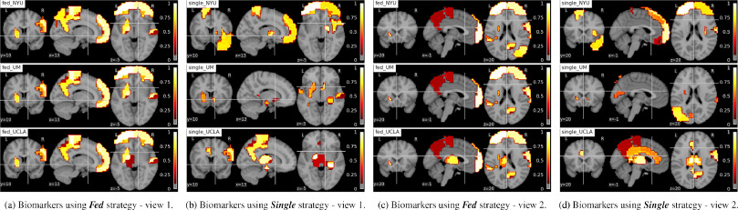

1. [Download : Download high-res image (858KB)](https://ars.els-cdn.com/content/image/1-s2.0-S1361841520301298-gr12_lrg.jpg)
2. [Download : Download full-size image](https://ars.els-cdn.com/content/image/1-s2.0-S1361841520301298-gr12.jpg)

Fig. 12. Interpreting brain biomarkers associated with identifying **Male** among ASD subjects from federated learning model (*Fed*) and using single site data for training (*Single*). The colors stand for the relative importance scores of the ROIs and the values are denoted on the color bar. The names of the strategies and sites are denoted on the left-upper corners of each subfigure. Each row shows the results of NYU, UM, UCLA site from top to bottom. (For interpretation of the references to colour in this figure legend, the reader is referred to the web version of this article.)

## References

**Alaerts, Swinnen, Wenderoth, 2016**

K. Alaerts, S.P. Swinnen, N. Wenderoth

**Sex differences in autism: a resting-state fmri investigation of functional brain connectivity in males and females**

Soc. Cogn. Affect. Neurosci., 11 (6) (2016), pp. 1002-1016

[CrossRef](https://doi.org/10.1093/scan/nsw027)[View Record in Scopus](https://www.scopus.com/inward/record.url?eid=2-s2.0-84979080329&partnerID=10&rel=R3.0.0)Google Scholar

**Chaudhuri, Imola, Machanavajjhala, 2019**

K. Chaudhuri, J. Imola, A. Machanavajjhala

**Capacity bounded differential privacy**

Advances in Neural Information Processing Systems (2019), pp. 3469-3478

[View Record in Scopus](https://www.scopus.com/inward/record.url?eid=2-s2.0-85087896055&partnerID=10&rel=R3.0.0)[Google Scholar](https://scholar.google.com/scholar_lookup?title=Capacity%20bounded%20differential%20privacy&publication_year=2019&author=K.%20Chaudhuri&author=J.%20Imola&author=A.%20Machanavajjhala)

**Chen, Dou, Chen, Qin, Heng, 2019**

C. Chen, Q. Dou, H. Chen, J. Qin, P.-A. Heng

**Synergistic image and feature adaptation: Towards cross-modality domain adaptation for medical image segmentation**

Proceedings of the AAAI Conference on Artificial Intelligence, 33 (2019), pp. 865-872

[CrossRef](https://doi.org/10.1609/aaai.v33i01.3301865)[View Record in Scopus](https://www.scopus.com/inward/record.url?eid=2-s2.0-85079236077&partnerID=10&rel=R3.0.0)Google Scholar

**Dean, Corrado, Monga, Chen, Devin, Mao, Ranzato, Senior, Tucker, Yang, et al., 2012**

J. Dean, G. Corrado, R. Monga, K. Chen, M. Devin, M. Mao, M. Ranzato, A. Senior, P. Tucker, K. Yang, *et al.*

**Large scale distributed deep networks**

Advances in neural information processing systems (2012), pp. 1223-1231

[View Record in Scopus](https://www.scopus.com/inward/record.url?eid=2-s2.0-84877760312&partnerID=10&rel=R3.0.0)Google Scholar

**Di Martino, Yan, Li, Denio, Castellanos, Alaerts, Anderson, Assaf, Bookheimer, Dapretto, et al., 2014**

A. Di Martino, C.-G. Yan, Q. Li, E. Denio, F.X. Castellanos, K. Alaerts, J.S. Anderson, M. Assaf, S.Y. Bookheimer, M. Dapretto, *et al.*

**The autism brain imaging data exchange: towards a large-scale evaluation of the intrinsic brain architecture in autism**

Mol. Psychiatry, 19 (6) (2014), p. 659

[CrossRef](https://doi.org/10.1038/mp.2013.78)[View Record in Scopus](https://www.scopus.com/inward/record.url?eid=2-s2.0-84901284227&partnerID=10&rel=R3.0.0)Google Scholar

**Du, Fu, Calhoun, 2018**

Y. Du, Z. Fu, V.D. Calhoun

**Classification and prediction of brain disorders using functional connectivity: promising but challenging**

Front. Neurosci., 12 (2018)

Google Scholar

**Dwork, Kenthapadi, McSherry, Mironov, Naor, 2006**

C. Dwork, K. Kenthapadi, F. McSherry, I. Mironov, M. Naor

**Our data, ourselves: Privacy via distributed noise generation**

Annual International Conference on the Theory and Applications of Cryptographic Techniques, Springer (2006), pp. 486-503

[CrossRef](https://doi.org/10.1007/11761679_29)[View Record in Scopus](https://www.scopus.com/inward/record.url?eid=2-s2.0-33746037200&partnerID=10&rel=R3.0.0)Google Scholar

**Dwork, McSherry, Nissim, Smith, 2006**

C. Dwork, F. McSherry, K. Nissim, A. Smith

**Calibrating noise to sensitivity in private data analysis**

Theory of cryptography conference, Springer (2006), pp. 265-284

[CrossRef](https://doi.org/10.1007/11681878_14)[View Record in Scopus](https://www.scopus.com/inward/record.url?eid=2-s2.0-33745556605&partnerID=10&rel=R3.0.0)Google Scholar

**Dwork, Roth, et al., 2014**

C. Dwork, A. Roth, *et al.*

**The algorithmic foundations of differential privacy**

Foundations and Trends® in Theoretical Computer Science, 9 (3–4) (2014), pp. 211-407

[View Record in Scopus](https://www.scopus.com/inward/record.url?eid=2-s2.0-84961990007&partnerID=10&rel=R3.0.0)[Google Scholar](https://scholar.google.com/scholar_lookup?title=The%20algorithmic%20foundations%20of%20differential%20privacy&publication_year=2014&author=C.%20Dwork&author=A.%20Roth)

**Ganin, Lempitsky, 2014**

Y. Ganin, V. Lempitsky

**Unsupervised domain adaptation by backpropagation**

arXiv preprint arXiv:1409.7495 (2014)

[Google Scholar](https://scholar.google.com/scholar_lookup?title=Unsupervised%20domain%20adaptation%20by%20backpropagation&publication_year=2014&author=Y.%20Ganin&author=V.%20Lempitsky)

**Ghifary, Kleijn, Zhang, Balduzzi, Li, 2016**

M. Ghifary, W.B. Kleijn, M. Zhang, D. Balduzzi, W. Li

**Deep reconstruction-classification networks for unsupervised domain adaptation**

European Conference on Computer Vision, Springer (2016), pp. 597-613

[CrossRef](https://doi.org/10.1007/978-3-319-46493-0_36)[View Record in Scopus](https://www.scopus.com/inward/record.url?eid=2-s2.0-84990068644&partnerID=10&rel=R3.0.0)Google Scholar

**Gholami, Sahu, Rudovic, Bousmalis, Pavlovic, 2018**

B. Gholami, P. Sahu, O. Rudovic, K. Bousmalis, V. Pavlovic

**Unsupervised multi-target domain adaptation: an information theoretic approach**

arXiv preprint arXiv:1810.11547 (2018)

Google Scholar

**Heinsfeld, Franco, Craddock, Buchweitz, Meneguzzi, 2018**

A.S. Heinsfeld, A.R. Franco, R.C. Craddock, A. Buchweitz, F. Meneguzzi

**Identification of autism spectrum disorder using deep learning and the abide dataset**

NeuroImage: Clinical, 17 (2018), pp. 16-23

[Article](https://www.sciencedirect.com/science/article/pii/S2213158217302073)[Download PDF](https://www.sciencedirect.com/science/article/pii/S2213158217302073/pdfft?md5=7808b6aaeb388997b863f2d375361ad5&pid=1-s2.0-S2213158217302073-main.pdf)[View Record in Scopus](https://www.scopus.com/inward/record.url?eid=2-s2.0-85030322624&partnerID=10&rel=R3.0.0)Google Scholar

**Heitmueller, Henderson, Warburton, Elmagarmid, Pentland, Darzi, 2014**

A. Heitmueller, S. Henderson, W. Warburton, A. Elmagarmid, A.S. Pentland, A. Darzi

**Developing public policy to advance the use of big data in health care**

Health Aff., 33 (9) (2014), pp. 1523-1530

[CrossRef](https://doi.org/10.1377/hlthaff.2014.0771)[View Record in Scopus](https://www.scopus.com/inward/record.url?eid=2-s2.0-84907060454&partnerID=10&rel=R3.0.0)Google Scholar

**Hoffman, Mohri, Zhang, 2018**

J. Hoffman, M. Mohri, N. Zhang

**Algorithms and theory for multiple-source adaptation**

Advances in Neural Information Processing Systems (2018), pp. 8246-8256

[View Record in Scopus](https://www.scopus.com/inward/record.url?eid=2-s2.0-85064817980&partnerID=10&rel=R3.0.0)[Google Scholar](https://scholar.google.com/scholar_lookup?title=Algorithms%20and%20theory%20for%20multiple-source%20adaptation&publication_year=2018&author=J.%20Hoffman&author=M.%20Mohri&author=N.%20Zhang)

**Ji, Pan, Long, Li, Jiang, Huang, 2019**

S. Ji, S. Pan, G. Long, X. Li, J. Jiang, Z. Huang

**Learning private neural language modeling with attentive aggregation**

2019 International Joint Conference on Neural Networks (IJCNN), IEEE (2019), pp. 1-8

[CrossRef](https://doi.org/10.1109/ijcnn.2019.8852464)[View Record in Scopus](https://www.scopus.com/inward/record.url?eid=2-s2.0-85062359011&partnerID=10&rel=R3.0.0)Google Scholar

**Li, Sahu, Talwalkar, Smith, 2019**

T. Li, A.K. Sahu, A. Talwalkar, V. Smith

**Federated learning: challenges, methods, and future directions**

arXiv preprint arXiv:1908.07873 (2019)

Google Scholar

**Lewis, 2020**

Lewis, *et al.*

**Decentralized distribution-sampled classification models with application to brain imaging**

Journal of neuroscience methods (2020)

[Google Scholar](https://scholar.google.com/scholar_lookup?title=Decentralized%20distribution-sampled%20classification%20models%20with%20application%20to%20brain%20imaging&publication_year=2020&author=Lewis)

**Li, Milletarì, Xu, Rieke, Hancox, Zhu, Baust, Cheng, Ourselin, Cardoso, et al., 2019**

W. Li, F. Milletarì, D. Xu, N. Rieke, J. Hancox, W. Zhu, M. Baust, Y. Cheng, S. Ourselin, M.J. Cardoso, *et al.*

**Privacy-preserving federated brain tumour segmentation**

International Workshop on Machine Learning in Medical Imaging, Springer (2019), pp. 133-141

[CrossRef](https://doi.org/10.1007/978-3-030-32692-0_16)[View Record in Scopus](https://www.scopus.com/inward/record.url?eid=2-s2.0-85075695218&partnerID=10&rel=R3.0.0)Google Scholar

**Long, Cao, Wang, Jordan, 2015**

M. Long, Y. Cao, J. Wang, M.I. Jordan

**Learning transferable features with deep adaptation networks**

arXiv preprint arXiv:1502.02791 (2015)

Google Scholar

**Long, Cao, Wang, Jordan, 2018**

M. Long, Z. Cao, J. Wang, M.I. Jordan

**Conditional adversarial domain adaptation**

Advances in Neural Information Processing Systems (2018), pp. 1640-1650

[View Record in Scopus](https://www.scopus.com/inward/record.url?eid=2-s2.0-85064843763&partnerID=10&rel=R3.0.0)[Google Scholar](https://scholar.google.com/scholar_lookup?title=Conditional%20adversarial%20domain%20adaptation&publication_year=2018&author=M.%20Long&author=Z.%20Cao&author=J.%20Wang&author=M.I.%20Jordan)

**Long, Zhu, Wang, Jordan, 2017**

M. Long, H. Zhu, J. Wang, M.I. Jordan

**Deep transfer learning with joint adaptation networks**

Proceedings of the 34th International Conference on Machine Learning-Volume 70, JMLR. org (2017), pp. 2208-2217

[View Record in Scopus](https://www.scopus.com/inward/record.url?eid=2-s2.0-85006082474&partnerID=10&rel=R3.0.0)[Google Scholar](https://scholar.google.com/scholar_lookup?title=Deep%20transfer%20learning%20with%20joint%20adaptation%20networks&publication_year=2017&author=M.%20Long&author=H.%20Zhu&author=J.%20Wang&author=M.I.%20Jordan)

**Maaten, Hinton, 2008**

L.v.d. Maaten, G. Hinton

**Visualizing data using t-sne**

Journal of machine learning research, 9 (Nov) (2008), pp. 2579-2605

[View Record in Scopus](https://www.scopus.com/inward/record.url?eid=2-s2.0-85052477931&partnerID=10&rel=R3.0.0)[Google Scholar](https://scholar.google.com/scholar_lookup?title=Visualizing%20data%20using%20t-sne&publication_year=2008&author=L.v.d.%20Maaten&author=G.%20Hinton)

**Masoudnia, Ebrahimpour, 2014**

S. Masoudnia, R. Ebrahimpour

**Mixture of experts: a literature survey**

Artif. Intell. Rev., 42 (2) (2014), pp. 275-293

[CrossRef](https://doi.org/10.1007/s10462-012-9338-y)[View Record in Scopus](https://www.scopus.com/inward/record.url?eid=2-s2.0-84904855059&partnerID=10&rel=R3.0.0)[Google Scholar](https://scholar.google.com/scholar_lookup?title=Mixture%20of%20experts%3A%20a%20literature%20survey&publication_year=2014&author=S.%20Masoudnia&author=R.%20Ebrahimpour)

**McMahan, Moore, Ramage, Agüera y Arcas**

McMahan, H., Moore, E., Ramage, D., Agüera y Arcas, B., 2016. Federated learning of deep networks using model averaging.

[Google Scholar](https://scholar.google.com/scholar?q=McMahan,%20H.,%20Moore,%20E.,%20Ramage,%20D.,%20Ag%C3%BCera%20y%20Arcas,%20B.,%202016.%20Federated%20learning%20of%20deep%20networks%20using%20model%20averaging.)

**Mohri, Sivek, Suresh, 2019**

M. Mohri, G. Sivek, A.T. Suresh

**Agnostic federated learning**

arXiv preprint arXiv:1902.00146 (2019)

[Google Scholar](https://scholar.google.com/scholar_lookup?title=Agnostic%20federated%20learning&publication_year=2019&author=M.%20Mohri&author=G.%20Sivek&author=A.T.%20Suresh)

**Nishio, Yonetani, 2019**

T. Nishio, R. Yonetani

**Client selection for federated learning with heterogeneous resources in mobile edge**

ICC 2019-2019 IEEE International Conference on Communications (ICC), IEEE (2019), pp. 1-7

[CrossRef](https://doi.org/10.1109/icc.2019.8761315)[View Record in Scopus](https://www.scopus.com/inward/record.url?eid=2-s2.0-85089427831&partnerID=10&rel=R3.0.0)Google Scholar

**Peng, Huang, Zhu, Saenko, 2019**

X. Peng, Z. Huang, Y. Zhu, K. Saenko

**Federated adversarial domain adaptation**

arXiv preprint arXiv:1911.02054 (2019)

[Google Scholar](https://scholar.google.com/scholar_lookup?title=Federated%20adversarial%20domain%20adaptation&publication_year=2019&author=X.%20Peng&author=Z.%20Huang&author=Y.%20Zhu&author=K.%20Saenko)

**Peterson, Kanani, Marathe, 2019**

D. Peterson, P. Kanani, V.J. Marathe

**Private federated learning with domain adaptation**

arXiv preprint arXiv:1912.06733 (2019)

[Google Scholar](https://scholar.google.com/scholar_lookup?title=Private%20federated%20learning%20with%20domain%20adaptation&publication_year=2019&author=D.%20Peterson&author=P.%20Kanani&author=V.J.%20Marathe)

**POLICY, THIS, OR**

POLICY, I.D.C.B.T., THIS, I., OR, P. V. B. O. R., 2003. Cdc/atsdr policy on releasing and sharing data.

[Google Scholar](https://scholar.google.com/scholar?q=POLICY,%20I.D.C.B.T.,%20THIS,%20I.,%20OR,%20P.%20V.%20B.%20O.%20R.,%202003.%20Cdcatsdr%20policy%20on%20releasing%20and%20sharing%20data.)

**Quionero-Candela, Sugiyama, Schwaighofer, Lawrence, 2009**

J. Quionero-Candela, M. Sugiyama, A. Schwaighofer, N.D. Lawrence

**Dataset shift in machine learning**

The MIT Press (2009)

Google Scholar

**Rosenbaum, Painter**

Rosenbaum, S.J., Painter, M.W., 2005. Assessing legal implications of using health data to improve health care quality and eliminate health care disparities.

Google Scholar

**Roski, Bo-Linn, Andrews, 2014**

J. Roski, G.W. Bo-Linn, T.A. Andrews

**Creating value in health care through big data: opportunities and policy implications**

Health Aff., 33 (7) (2014), pp. 1115-1122

[CrossRef](https://doi.org/10.1377/hlthaff.2014.0147)[View Record in Scopus](https://www.scopus.com/inward/record.url?eid=2-s2.0-84905981088&partnerID=10&rel=R3.0.0)Google Scholar

**Shazeer, Mirhoseini, Maziarz, Davis, Le, Hinton, Dean, 2017**

N. Shazeer, A. Mirhoseini, K. Maziarz, A. Davis, Q. Le, G. Hinton, J. Dean

**Outrageously large neural networks: the sparsely-gated mixture-of-experts layer**

arXiv preprint arXiv:1701.06538 (2017)

Google Scholar

**Sheller, Reina, Edwards, Martin, Bakas, 2018**

M.J. Sheller, G.A. Reina, B. Edwards, J. Martin, S. Bakas

**Multi-institutional deep learning modeling without sharing patient data: A feasibility study on brain tumor segmentation**

International MICCAI Brainlesion Workshop, Springer (2018), pp. 92-104

[View Record in Scopus](https://www.scopus.com/inward/record.url?eid=2-s2.0-85067441456&partnerID=10&rel=R3.0.0)Google Scholar

**Shen, Wu, Suk, 2017**

D. Shen, G. Wu, H.-I. Suk

**Deep learning in medical image analysis**

Annu. Rev. Biomed. Eng., 19 (2017), pp. 221-248

[CrossRef](https://doi.org/10.1146/annurev-bioeng-071516-044442)[View Record in Scopus](https://www.scopus.com/inward/record.url?eid=2-s2.0-85021145223&partnerID=10&rel=R3.0.0)[Google Scholar](https://scholar.google.com/scholar_lookup?title=Deep%20learning%20in%20medical%20image%20analysis&publication_year=2017&author=D.%20Shen&author=G.%20Wu&author=H.-I.%20Suk)

**Shokri, Shmatikov, 2015**

R. Shokri, V. Shmatikov

**Privacy-preserving deep learning**

Proceedings of the 22nd ACM SIGSAC conference on computer and communications security, ACM (2015), pp. 1310-1321

[CrossRef](https://doi.org/10.1145/2810103.2813687)[View Record in Scopus](https://www.scopus.com/inward/record.url?eid=2-s2.0-84954108845&partnerID=10&rel=R3.0.0)[Google Scholar](https://scholar.google.com/scholar_lookup?title=Privacy-preserving%20deep%20learning&publication_year=2015&author=R.%20Shokri&author=V.%20Shmatikov)

**Simonyan, Vedaldi, Zisserman**

Simonyan, K., Vedaldi, A., Zisserman, A., 2013. Deep inside convolutional networks: Visualising image classification models and saliency maps. arXiv:1312.6034.

Google Scholar

**Springenberg, Dosovitskiy, Brox, Riedmiller, 2014**

J.T. Springenberg, A. Dosovitskiy, T. Brox, M. Riedmiller

**Striving for simplicity: the all convolutional net**

arXiv preprint arXiv:1412.6806 (2014)

Google Scholar

**Suk, Wee, Lee, Shen, 2016**

H.-I. Suk, C.-Y. Wee, S.-W. Lee, D. Shen

**State-space model with deep learning for functional dynamics estimation in resting-state fmri**

Neuroimage, 129 (2016), pp. 292-307

[Article](https://www.sciencedirect.com/science/article/pii/S1053811916000100)[Download PDF](https://www.sciencedirect.com/science/article/pii/S1053811916000100/pdfft?md5=5579226fd4ab23be9968bdb3555572cc&pid=1-s2.0-S1053811916000100-main.pdf)[View Record in Scopus](https://www.scopus.com/inward/record.url?eid=2-s2.0-84957052106&partnerID=10&rel=R3.0.0)Google Scholar

**Sun, Saenko, 2016**

B. Sun, K. Saenko

**Deep coral: Correlation alignment for deep domain adaptation**

European Conference on Computer Vision, Springer (2016), pp. 443-450

[CrossRef](https://doi.org/10.1007/978-3-319-49409-8_35)[View Record in Scopus](https://www.scopus.com/inward/record.url?eid=2-s2.0-85006058961&partnerID=10&rel=R3.0.0)[Google Scholar](https://scholar.google.com/scholar_lookup?title=Deep%20coral%3A%20Correlation%20alignment%20for%20deep%20domain%20adaptation&publication_year=2016&author=B.%20Sun&author=K.%20Saenko)

**Tzeng, Hoffman, Saenko, Darrell, 2017**

E. Tzeng, J. Hoffman, K. Saenko, T. Darrell

**Adversarial discriminative domain adaptation**

Proceedings of the IEEE Conference on Computer Vision and Pattern Recognition (2017), pp. 7167-7176

[View Record in Scopus](https://www.scopus.com/inward/record.url?eid=2-s2.0-85068498242&partnerID=10&rel=R3.0.0)[Google Scholar](https://scholar.google.com/scholar_lookup?title=Adversarial%20discriminative%20domain%20adaptation&publication_year=2017&author=E.%20Tzeng&author=J.%20Hoffman&author=K.%20Saenko&author=T.%20Darrell)

**Tzeng, Hoffman, Zhang, Saenko, Darrell, 2014**

E. Tzeng, J. Hoffman, N. Zhang, K. Saenko, T. Darrell

**Deep domain confusion: maximizing for domain invariance**

arXiv preprint arXiv:1412.3474 (2014)

Google Scholar

**Varoquaux, Thirion, 2014**

G. Varoquaux, B. Thirion

**How machine learning is shaping cognitive neuroimaging**

Gigascience, 3 (1) (2014), p. 28

[View Record in Scopus](https://www.scopus.com/inward/record.url?eid=2-s2.0-84941315259&partnerID=10&rel=R3.0.0)[Google Scholar](https://scholar.google.com/scholar_lookup?title=How%20machine%20learning%20is%20shaping%20cognitive%20neuroimaging&publication_year=2014&author=G.%20Varoquaux&author=B.%20Thirion)

**Wang, Yu, Dunlap, Ma, Wang, Mirhoseini, Darrell, Gonzalez, 2018**

X. Wang, F. Yu, L. Dunlap, Y.-A. Ma, R. Wang, A. Mirhoseini, T. Darrell, J.E. Gonzalez

**Deep mixture of experts via shallow embedding**

arXiv preprint arXiv:1806.01531 (2018)

Google Scholar

**Weimer, Vining, 2017**

D.L. Weimer, A.R. Vining

**Policy analysis: Concepts and practice**

Routledge (2017)

[Google Scholar](https://scholar.google.com/scholar_lookup?title=Policy%20analysis%3A%20Concepts%20and%20practice&publication_year=2017&author=D.L.%20Weimer&author=A.R.%20Vining)

**Yang, Dvornek, Zhang, Chapiro, Lin, Duncan, 2019**

J. Yang, N.C. Dvornek, F. Zhang, J. Chapiro, M. Lin, J.S. Duncan

**Unsupervised domain adaptation via disentangled representations: Application to cross-modality liver segmentation**

International Conference on Medical Image Computing and Computer-Assisted Intervention, Springer (2019), pp. 255-263

[CrossRef](https://doi.org/10.1007/978-3-030-32245-8_29)[View Record in Scopus](https://www.scopus.com/inward/record.url?eid=2-s2.0-85075699448&partnerID=10&rel=R3.0.0)Google Scholar

**Yang, Liu, Chen, Tong, 2019**

Q. Yang, Y. Liu, T. Chen, Y. Tong

**Federated machine learning: concept and applications**

ACM Transactions on Intelligent Systems and Technology (TIST), 10 (2) (2019), p. 12

[Article](https://www.sciencedirect.com/science/article/pii/S002195171930171X)[Download PDF](https://www.sciencedirect.com/science/article/pii/S002195171930171X/pdfft?md5=b2859705f159f0e7fbec57d189709046&pid=1-s2.0-S002195171930171X-main.pdf)[View Record in Scopus](https://www.scopus.com/inward/record.url?eid=2-s2.0-85098709418&partnerID=10&rel=R3.0.0)[Google Scholar](https://scholar.google.com/scholar_lookup?title=Federated%20machine%20learning%3A%20concept%20and%20applications&publication_year=2019&author=Q.%20Yang&author=Y.%20Liu&author=T.%20Chen&author=Y.%20Tong)

**Yao, Zhang, Li, Ye, 2019**

Y. Yao, Y. Zhang, X. Li, Y. Ye

**Heterogeneous domain adaptation via soft transfer network**

Proceedings of the 27th ACM International Conference on Multimedia (2019), pp. 1578-1586

[CrossRef](https://doi.org/10.1145/3343031.3350955)[View Record in Scopus](https://www.scopus.com/inward/record.url?eid=2-s2.0-85074870905&partnerID=10&rel=R3.0.0)[Google Scholar](https://scholar.google.com/scholar_lookup?title=Heterogeneous%20domain%20adaptation%20via%20soft%20transfer%20network&publication_year=2019&author=Y.%20Yao&author=Y.%20Zhang&author=X.%20Li&author=Y.%20Ye)

**Yarkoni, Poldrack, Nichols, Van Essen, Wager, 2011**

T. Yarkoni, R.A. Poldrack, T.E. Nichols, D.C. Van Essen, T.D. Wager

**Large-scale automated synthesis of human functional neuroimaging data**

Nat. Methods, 8 (8) (2011), p. 665

[CrossRef](https://doi.org/10.1038/nmeth.1635)[View Record in Scopus](https://www.scopus.com/inward/record.url?eid=2-s2.0-79960978681&partnerID=10&rel=R3.0.0)Google Scholar

**Zhao, Li, Yue, Gu, Xu, Hu, Chai, Keutzer, 2019**

S. Zhao, B. Li, X. Yue, Y. Gu, P. Xu, R. Hu, H. Chai, K. Keutzer

**Multi-source domain adaptation for semantic segmentation**

Advances in Neural Information Processing Systems (2019), pp. 7285-7298

[View Record in Scopus](https://www.scopus.com/inward/record.url?eid=2-s2.0-85085602958&partnerID=10&rel=R3.0.0)Google Scholar

**Zhou, 2012**

Z.-H. Zhou

**Ensemble methods: Foundations and algorithms**

Chapman and Hall/CRC (2012)

[Google Scholar](https://scholar.google.com/scholar_lookup?title=Ensemble%20methods%3A%20Foundations%20and%20algorithms&publication_year=2012&author=Z.-H.%20Zhou)

**Zhu, Park, Isola, Efros, 2017**

J.-Y. Zhu, T. Park, P. Isola, A.A. Efros

**Unpaired image-to-image translation using cycle-consistent adversarial networks**

Proceedings of the IEEE international conference on computer vision (2017), pp. 2223-2232

[View Record in Scopus](https://www.scopus.com/inward/record.url?eid=2-s2.0-85040908647&partnerID=10&rel=R3.0.0)Google Scholar

**Zhu, Liu, Han**

Zhu, L., Liu, Z., Han, S., 2019. Deep leakage from gradients. arXiv:1906.08935.

[Google Scholar](https://scholar.google.com/scholar?q=Zhu,%20L.,%20Liu,%20Z.,%20Han,%20S.,%202019.%20Deep%20leakage%20from%20gradients.%20arXiv:1906.08935.)

**<sup>1</sup>**

This work was done at Yale University.

**<sup>2</sup>**

YG and ND had equal contribution.

© 2020 The Authors. Published by Elsevier B.V.

### R-fMRI reconstruction from *k*–*t* undersampled data using a subject-invariant dictionary model and VB-EM with nested minorization

- Medical Image Analysis, Volume 65, 2020, Article 101752

### Brain graph super-resolution for boosting neurological disorder diagnosis using unsupervised multi-topology connectional brain template learning

- Medical Image Analysis, Volume 65, 2020, Article 101768

### Joint functional brain network atlas estimation and feature selection for neurological disorder diagnosis with application to autism

- Medical Image Analysis, Volume 60, 2020, Article 101596

12